# HW 07: Data Importing and Wrangling I

Andrea Winingar

19 July 2020

Load the packages and make link to data.

```r
library(here)
```

### Limpets

```r
limpets_data <- read_csv(here('data','limpets.csv'))
```

The data is tidy.

using col_types argument.

```r
limpets_data <- read_csv("limpets.csv", col_types = "ncc")
```

[output not shown]

Factor Site column.

```r
factor(limpets_data$Site, levels = c('PBL', 'KNRM', 'VBG', 'WP', 'PF', 'DP', 'SIO', 'CTZ1', 'CTZ2', 'CNM'))
```

[output not shown]

[output cut: 46 more lines]

Boxplot of limpets_data

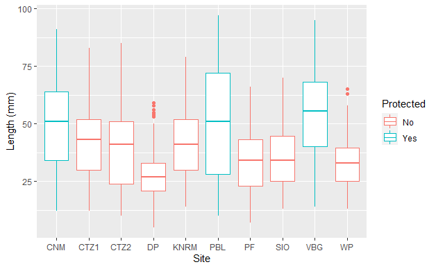

DP and WP have outliers. The protected sites have larger limpets than nonprotected sites.The protected sites also have a larger box range.

### Roseate Terns

Load the data.

```r
roseate_data <- read_tsv(here("data", "roseate_terns.txt"))
```

The data is not tidy. This next code chunk will tidy it.

```r
roseate_tidy <- roseate_data %>%
  pivot_longer(`AR`:`JC`,
               names_to = "Site",
               values_to = "Population")
```

[output not shown]

Use filter to remove sites with missing counts.

| year | Site | Population |
| --- | --- | --- |
| 1992 | AR | 378 |
| 1992 | AL | 76 |
| 1992 | AC | 29 |
| 1992 | BR | 378 |
| 1992 | BC | 29 |
| 1992 | JR | 651 |
| 1992 | JC | 35 |
| 1993 | AR | 427 |
| 1993 | AL | 76 |
| 1993 | AC | 28 |

[output cut: 204 more lines]

Make Lineplot of pop size over time.

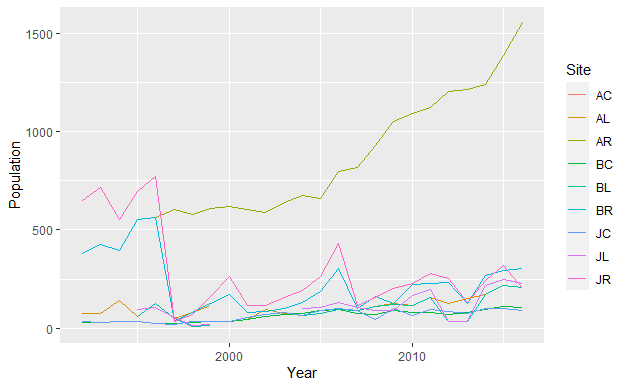

Sites BC, JC, AR all increased in population, AR increased the most dramatically. JR, BR both decreased drastically and all others did not have any significant changes. The non continuos ones could be caused by the population being NA and was removed.

### Blacklip Abalone

Chunk 1: Import, remove the first column, then make a boxplot of height differences among the three types.

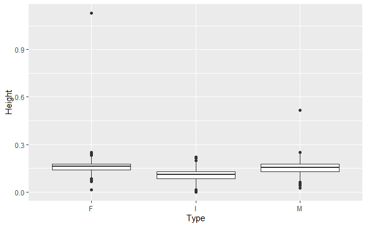

There are two outliers, one in the F and one in M.

Chunk 2: scatterplot to see if height appears to correlate with rings.

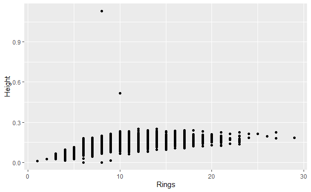

Height correlates to Rings to an extent, but no enough to explain or cause the outliers.

Chunk 3:remove outlier by filtering. Make Type an ordered factor. Redo scatterplot.

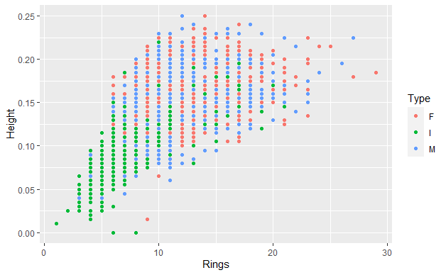

Immatures are generally smaller, males and females are mixed together without either being distinguishably smaller or larger. There are some male and females that are smaller than the immatures.

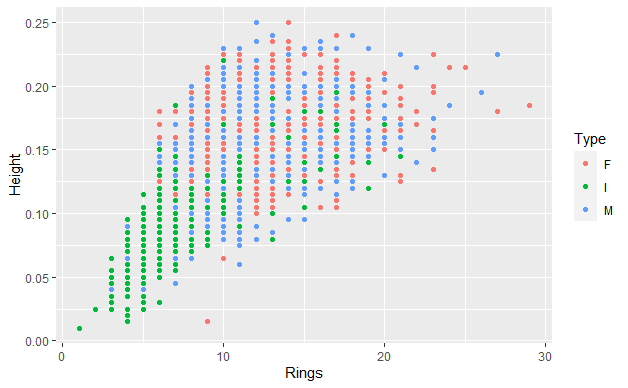

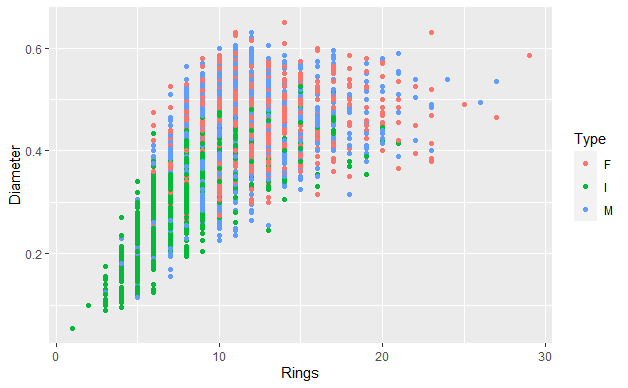

### Darters

Load the data.

```r
darters_data <- read_fwf(here('data', 'darter.txt'), fwf_widths(c(3, 11, 1, 1, 1, 3, 4, 4, 4, 3, 3, 2, 2)), comment = '#')
```

Chunk 1: Make column titles, make riffle an unordered factor, and make major_type an ordered factor.

```r
darter_renamed$Maj_Type <- factor(darter_renamed$Maj_Type, levels = c('s', 'fg', 'sg', 'lg', 'c'), ordered = TRUE)
```

[output not shown]

Chunk 2: Use filter to remove zonale and tetrazonum. Remove columns min_sub and min_type. Rename maj_sub and maj_type. arrange by id.

| ID | Species | Riffle | Age | Sex | Length | Depth | Velocity | Temperature | major_substrate | major_type |
| --- | --- | --- | --- | --- | --- | --- | --- | --- | --- | --- |
| 1 | blennioides | 1 | 0 | m | NA | 43.0 | 0.53 | 23.7 | 0.8 | s |
| 2 | blennioides | 1 | 0 | m | 2.9 | 28.0 | 0.47 | 28.1 | 0.7 | c |
| 3 | blennioides | 1 | 1 | f | 3.1 | 8.0 | 0.39 | 30.2 | 0.6 | lg |
| 4 | blennioides | 1 | 1 | f | 3.3 | 59.0 | 0.34 | 25.4 | 0.5 | sg |
| 5 | blennioides | 1 | 1 | m | 3.5 | 27.0 | 0.34 | 28.0 | 0.8 | lg |
| 6 | blennioides | 1 | 1 | m | 3.6 | 7.0 | 0.36 | 24.0 | 0.6 | sg |
| 7 | blennioides | 1 | 1 | m | 3.7 | 13.5 | 0.61 | 29.4 | 0.6 | lg |
| 8 | blennioides | 1 | 1 | m | 3.7 | 27.0 | 0.34 | 28.0 | 0.5 | lg |
| 9 | blennioides | 1 | 1 | f | 3.8 | 11.5 | 0.34 | 30.0 | 0.6 | lg |
| 10 | blennioides | 1 | 1 | m | 3.8 | 12.0 | 0.39 | 29.8 | 0.6 | lg |

[output cut: 109 more lines]

Plot 1: length as a function of depth, species to color and shape, facet_wrap() on riffles.

```
Ignoring unknown aesthetics: Shape
```

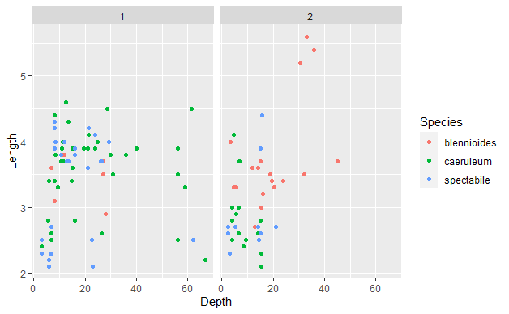

```r
darter_renamed %>%
  ggplot() +
  geom_point(mapping = aes(x = Depth, y = Length, color = Species, Shape = Species)) +
  facet_wrap(~ Riffle, nrow = 1)
```

Riffle 2 has longer variables and riffle one has higher depths.

Plot 2: boxplot

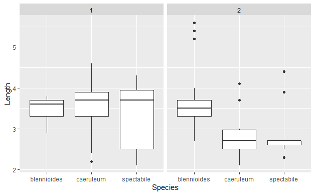

Riffle two has several outliers, riffle one only has asingle outlier.

Plot 3:boxplot

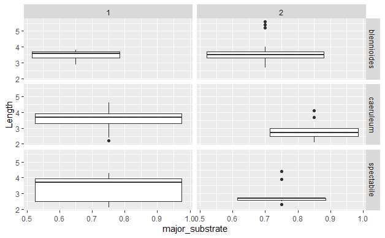

The order of Species and Riffle in facet_grid() determines if they represented horizontally across or vertically.